# Warmup 04

Rocky Lubbers

9/21/18

```r
library(readr)
nba = read_csv("/Users/rockylubbers/Desktop/STAT133/Homework/warmup04/nba2018.csv", col_types = cols(
    position = col_factor(c('C', 'PF', 'PG', 'SF', 'SG')),
    player= col_character(),
    team = col_character(),
    height = col_character(),
    birth_date = col_character(),
    country = col_character(),
    experience = col_character(),
    college = col_character(),
    salary = col_double(),
    field_goals_perc = col_double(),
    points3_perc = col_double(),
    points2_perc = col_double(),
    points1_perc = col_double(),
    effective_field_goal_perc = col_double()
    ))

str(nba)
```

```
## Classes 'tbl_df', 'tbl' and 'data.frame':    477 obs. of  38 variables:
##  $ player                   : chr  "Al Horford" "Amir Johnson" "Avery Bradley" "Demetrius Jackson" ...
##  $ number                   : chr  "42" "90" "0" "9" ...
##  $ team                     : chr  "BOS" "BOS" "BOS" "BOS" ...
##  $ position                 : Factor w/ 5 levels "C","PF","PG",..: 1 2 5 3 4 3 4 5 4 2 ...
##  $ height                   : chr  "6-10" "6-9" "6-2" "6-1" ...
##  $ weight                   : int  245 240 180 201 205 185 235 215 225 231 ...
##  $ birth_date               : chr  "June 3, 1986" "May 1, 1987" "November 26, 1990" "September 7, 1994" ...
##  $ country                  : chr  "do" "us" "us" "us" ...
##  $ experience               : chr  "9" "11" "6" "R" ...
##  $ college                  : chr  "University of Florida" NA "University of Texas at Austin" "University of Notre Dame" ...
##  $ salary                   : num  26540100 12000000 8269663 1450000 1410598 ...
##  $ rank                     : int  4 6 5 15 11 1 3 13 8 10 ...
##  $ age                      : int  30 29 26 22 31 27 26 21 20 29 ...
##  $ games                    : int  68 80 55 5 47 76 72 29 78 78 ...
##  $ games_started            : int  68 77 55 0 0 76 72 0 20 6 ...
##  $ minutes                  : int  2193 1608 1835 17 538 2569 2335 220 1341 1232 ...
##  $ field_goals              : int  379 213 359 3 95 682 333 25 192 114 ...
##  $ field_goals_atts         : int  801 370 775 4 232 1473 720 58 423 262 ...
##  $ field_goals_perc         : num  0.473 0.576 0.463 0.75 0.409 0.463 0.463 0.431 0.454 0.435 ...
##  $ points3                  : int  86 27 108 1 39 245 157 12 46 45 ...
##  $ points3_atts             : int  242 66 277 1 111 646 394 35 135 130 ...
##  $ points3_perc             : num  0.355 0.409 0.39 1 0.351 0.379 0.398 0.343 0.341 0.346 ...
##  $ points2                  : int  293 186 251 2 56 437 176 13 146 69 ...
##  $ points2_atts             : int  559 304 498 3 121 827 326 23 288 132 ...
##  $ points2_perc             : num  0.524 0.612 0.504 0.667 0.463 0.528 0.54 0.565 0.507 0.523 ...
##  $ effective_field_goal_perc: num  0.527 0.612 0.533 0.875 0.494 0.546 0.572 0.534 0.508 0.521 ...
##  $ points1                  : int  108 67 68 3 33 590 176 6 85 26 ...
##  $ points1_atts             : int  135 100 93 6 41 649 217 9 124 37 ...
##  $ points1_perc             : num  0.8 0.67 0.731 0.5 0.805 0.909 0.811 0.667 0.685 0.703 ...
##  $ off_rebounds             : int  95 118 65 2 16 43 48 6 45 59 ...
##  $ def_rebounds             : int  370 248 269 2 68 162 367 20 175 213 ...
##  $ total_rebounds           : int  465 366 334 4 84 205 415 26 220 272 ...
##  $ assists                  : int  337 140 122 3 33 448 155 4 64 71 ...
##  $ steals                   : int  52 51 68 0 9 70 73 10 35 25 ...
##  $ blocks                   : int  86 62 11 0 7 13 23 2 18 17 ...
##  $ turnovers                : int  115 77 88 0 25 210 80 4 68 39 ...
##  $ fouls                    : int  138 211 141 0 48 167 161 15 142 122 ...
##  $ points                   : int  952 520 894 10 262 2199 999 68 515 299 ...
##  - attr(*, "spec")=List of 2
```

[output cut: 68 more lines]

[output not shown]

# 2 Right After Importing Data

```r
#experience
summary(nba$experience)
```

```
##    Length     Class      Mode
##       477 character character
```

```r
nba$experience[nba$experience == 'R'] = 0
nba$experience = as.integer(nba$experience)
summary(nba$experience)
```

```
##    Min. 1st Qu.  Median    Mean 3rd Qu.    Max.
##   0.000   1.000   4.000   4.662   7.000  18.000
```

```r
#salary
nba$salary = nba$salary / 1000000
summary(nba$salary)
```

```
##      Min.   1st Qu.    Median      Mean   3rd Qu.      Max.
##  0.005145  1.050961  3.000000  5.804697  8.269663 30.963450
```

```r
#position
pos_names = c("center", "power_fwd", "point_guard", "small_fwd", "shoot_guard")
levels(nba$position) = pos_names
table(nba$position)
```

```
##
##      center   power_fwd point_guard   small_fwd shoot_guard
##          97          98          96          84         102
```

# 3 A bit of subscripting

```r
length(nba$player[which(nba$college == 'University of California, Los Angeles', TRUE)]) #number of players that went to UCLA
```

```
## [1] 14
```

```r
length(nba$player[which(nba$college == 'University of California, Berkeley', TRUE)]) #number of players that went to Cal
```

```
## [1] 0
```

```r
max(nba$weight) #max weight
```

```
## [1] 290
```

```r
nba$player[which.max(nba$weight)] #player with max weight
```

```
## [1] "Boban Marjanovic"
```

```r
mean(nba$weight) #average weight
```

```
## [1] 219.9119
```

```r
median(nba$salary) #median salary (in millions of dollars)
```

```
## [1] 3
```

```r
median(nba$salary[nba$experience >= 10]) #median salary with >= 10 years experience
```

```
## [1] 4.8375
```

```r
median(nba$salary[nba$position == "shoot_guard" | nba$position == "point_guard"]) #median salary of SGs and PGs
```

```
## [1] 2.789697
```

```r
median(nba$salary[nba$position == "power_fwd" & nba$age >= 30 & nba$weight >= 240]) #median salary of power forward, 30 or over, and 240 or overlbs
```

```
## [1] 8
```

```r
#Golden State Warriors Stats
gsw = data.frame(
  nba$player[nba$team == 'GSW'],
  nba$position[nba$team == 'GSW'],
  nba$height[nba$team == 'GSW'],
  nba$weight[nba$team == 'GSW'],
  nba$age[nba$team == 'GSW'])
colnames(gsw) = c("Player", "Possition", "Height", "Weight", "Age")
gsw
```

```
##                  Player   Possition Height Weight Age
## 1      Anderson Varejao      center   6-10    273  34
## 2        Andre Iguodala   small_fwd    6-6    215  33
## 3          Damian Jones      center    7-0    245  21
## 4            David West      center    6-9    250  36
## 5        Draymond Green   power_fwd    6-7    230  26
## 6             Ian Clark shoot_guard    6-3    175  25
## 7  James Michael McAdoo   power_fwd    6-9    230  24
## 8          JaVale McGee      center    7-0    270  29
## 9          Kevin Durant   power_fwd    6-9    240  28
## 10         Kevon Looney      center    6-9    220  20
## 11        Klay Thompson shoot_guard    6-7    215  26
## 12          Matt Barnes   small_fwd    6-7    226  36
## 13        Patrick McCaw shoot_guard    6-7    185  21
## 14     Shaun Livingston point_guard    6-7    192  31
## 15        Stephen Curry point_guard    6-3    190  28
## 16        Zaza Pachulia      center   6-11    270  32
```

# 4 Performance of Players

```r
nba$missed_field_goals = nba$field_goals_atts - nba$field_goals
nba$miseed_free_throws = nba$points1_atts
nba$rebounds = nba$total_rebounds
nba$mins_game = nba$minutes

EFF = (nba$points + nba$rebounds + nba$assists + nba$steals + nba$blocks - nba$missed_field_goals - nba$miseed_free_throws - nba$turnovers) / nba$games

nba$efficiency = EFF
summary(nba$efficiency)
```

```
##    Min. 1st Qu.  Median    Mean 3rd Qu.    Max.
##  -2.500   4.258   7.417   8.146  10.960  26.122
```

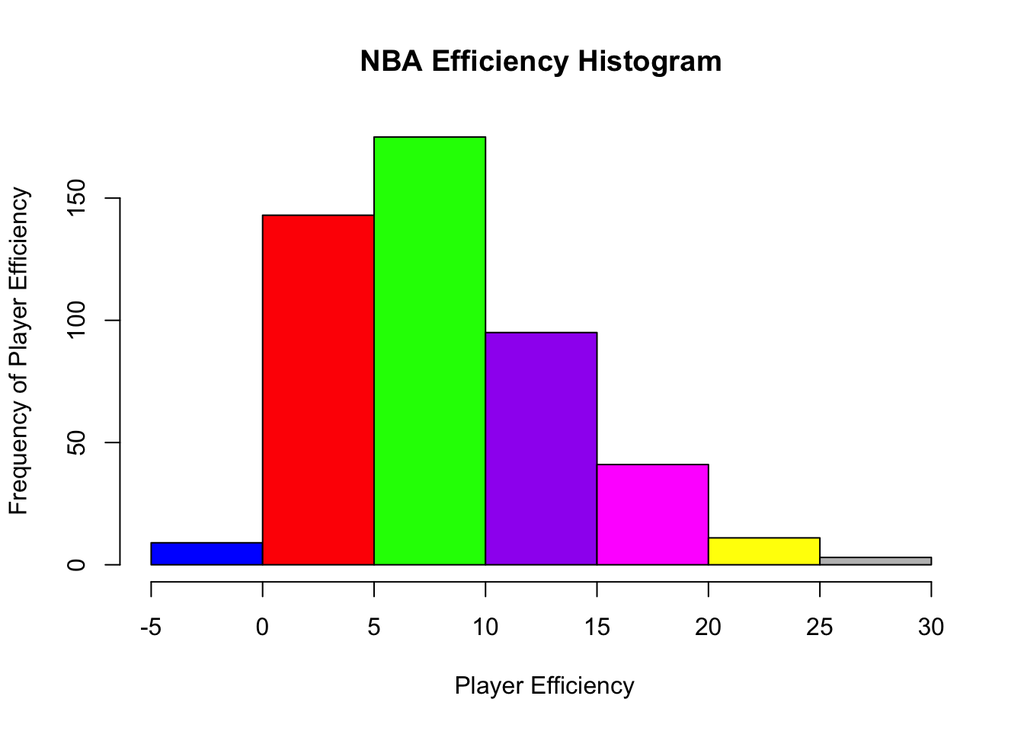

```r
hist(nba$efficiency, col = c("blue", "red", "green", "purple", "magenta", "yellow", "gray"), xlab=" Player Efficiency", ylab = "Frequency of Player Efficiency", main= "NBA Efficiency Histogram")
```

```r
topten = data.frame(
  nba$player[order(nba$efficiency, decreasing=TRUE)][1:10],
  nba$team[order(nba$efficiency, decreasing=TRUE)][1:10],
  nba$salary[order(nba$efficiency, decreasing=TRUE)][1:10],
  nba$efficiency[order(nba$efficiency, decreasing=TRUE)][1:10]
)
colnames(topten) = c("player", "team", "salary", "efficiency")
topten
```

```
##                   player team    salary efficiency
## 1           LeBron James  CLE 30.963450   26.12162
## 2     Karl-Anthony Towns  MIN  5.960160   25.96341
## 3      Russell Westbrook  OKC 26.540100   25.06173
## 4           Kevin Durant  GSW 26.540100   24.77419
## 5          Anthony Davis  NOP 22.116750   24.22667
## 6           James Harden  HOU 26.540100   23.17284
## 7           Nikola Jokic  DEN  1.358500   22.67123
## 8  Giannis Antetokounmpo  MIL  2.995421   22.48750
## 9       Hassan Whiteside  MIA 22.116750   22.45455
## 10      DeMarcus Cousins  NOP 16.957900   22.35294
```

```r
nba$player[nba$efficiency < 0] #NBA players with negative efficiency
```

```
## [1] "Gary Neal"       "Axel Toupane"    "Michael Gbinije" "Patricio Garino"
## [5] "Ben Bentil"
```

# 5 Further Exploration

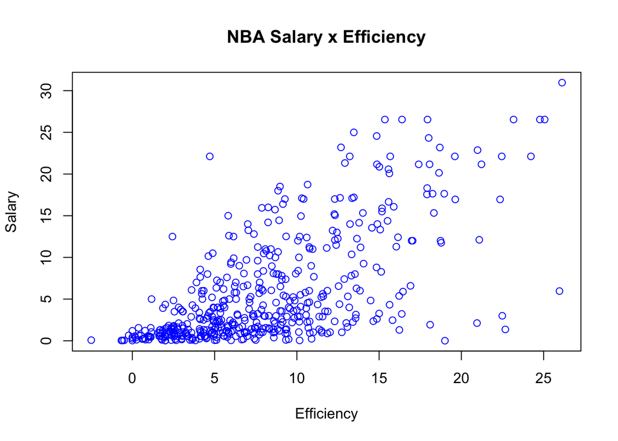

```r
# The more efficient a player is, the higher his salary?
plot(nba$efficiency, nba$salary, col="blue", xlab="Efficiency", ylab="Salary", main = "NBA Salary x Efficiency")
```

– As we can see in this graph, there seems to be a linear correlation with salary in respect to efficiency. This generally means that it is true that the more efficient a player is the higher his salary. However, there is a large cluster from 0-8 in efficiency, with no real increase in salary for the players. So many players in the NBA that are in this range of efficiency have around the same salaries as a majority of the players (who are also in this range). Yet, when the efficiency of a player increases over ~8, we start to see the linear correlation between salary and efficiency show.

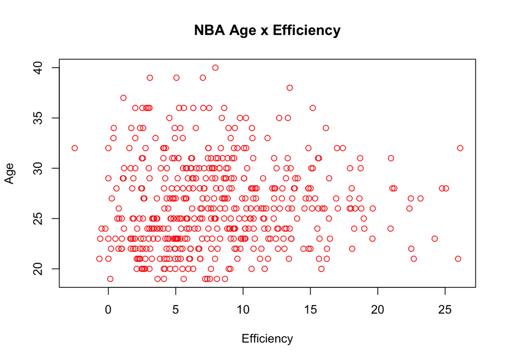

```r
# As players get older, do they tend to become more efficient?
plot(nba$efficiency, nba$age, col="red", xlab="Efficiency", ylab="Age", main = "NBA Age x Efficiency")
```

– When we plot Age against Efficiency for NBA players, we get no evidence that with age, players become more efficient. As we can see in this plot, there is not correlation in the data. We have widespread efficiency across all ages, with the most efficient age ~32, and least efficient age around ~32 as well.

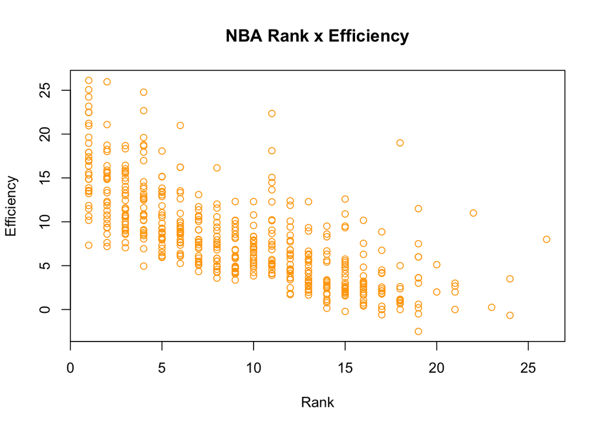

```r
# Does the rank of a player seem to be associated with his efficiency? (i.e more important the rank, more efficient?
plot(nba$rank, nba$efficiency, col="orange", xlab="Rank", ylab="Efficiency", main = "NBA Rank x Efficiency")
```

– As this plot shows, the rank of the player is highly associated with his efficiency. The more important the rank (i.e lower numbers on the x axis–rank 1 being most important) the higher the efficiency. Thus, when the rank decreases in importance (increases in value on x-axis), we see the efficiency start to fall linearly. Lower ranks, like 5-25 have much lower efficiency values than that of higher ranks 1-5.

# 6 Comments and Reflections